# Xenograft Protein Profiling Data

James Wade

November 14, 2016

## Using R to Plot Compiled Data

Here is the the code to analyze compiled data from multiplex protein detection in patient derived tumor xenografts under various treatments. Here is the code to access the data from GitHub:

```r
url <- "https://raw.githubusercontent.com/jwade1221/XenograftProteinProfiling/master/Combined_Averaged.csv"
filename <- basename(url)
download.file(url,destfile=filename)
```

```r
library(readr)
```

Here’s what the data looks like:

```r
head(dat)
```

| Time Point | Cell Line | Treatment | Target | Relative Shift | Standard Deviation |
| --- | --- | --- | --- | --- | --- |
| 1 | 26 | Palbociclib | hydroxy-HIF | 1115.5178 | 98.09873 |
| 1 | 26 | GDC0980 | hydroxy-HIF | 1349.0993 | 83.21165 |
| 1 | 26 | DMSO | hydroxy-HIF | 1162.3543 | 332.13049 |
| 1 | 26 | GNE-317 | hydroxy-HIF | 1113.2312 | 27.24431 |
| 1 | 26 | Erlotinib | hydroxy-HIF | 1187.9820 | 183.78099 |
| 1 | 26 | (+)-Serum | hydroxy-HIF | 978.5778 | 354.36011 |

### Plotting Each Target

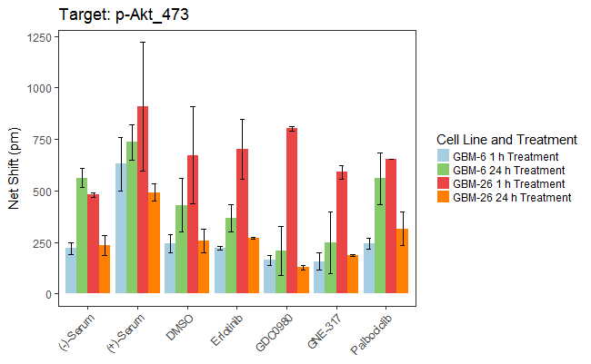

```r
plotEachTarget <- function(i, filename = "Combined_Averaged.csv"){
    library(readr)
    library(ggplot2)
    library(RColorBrewer)

    #import data
    dat <- read_csv(filename, col_types = cols())
    targetList <- unique(dat$Target)
    dat.Target <- dat[dat$Target == targetList[i],]

    #set error bars
    limits <- aes(ymax = `Relative Shift` + `Standard Deviation`,
                  ymin = `Relative Shift` - `Standard Deviation`)

    #get colors
    colorCount <- length(unique(dat$`Cell Line`)) +
                length(unique(dat$`Time Point`))
    getPalette <- colorRampPalette(brewer.pal(8, "Paired"))(colorCount)

    #plot figure
    plots <- ggplot(data = dat.Target,
                aes(x = Treatment, y = `Relative Shift`,
                fill = interaction(factor(`Time Point`), factor(`Cell Line`)),
                group = interaction(factor(`Time Point`), factor(`Cell Line`)))) +
        geom_bar(stat = "identity", position = "dodge") +
        ylab("Net Shift (pm)") +
        geom_errorbar(limits,position = position_dodge(width = 0.9),
                      width = 0.4) +
        theme_bw() + theme(panel.grid = element_blank(),
                axis.title.x=element_blank()) +
        theme(axis.text.x = element_text(angle = 45, hjust = 1))+
        scale_fill_manual(values = getPalette, name="Cell Line and Treatment",
                labels=c("GBM-6 1 h Treatment", "GBM-6 24 h Treatment",
                "GBM-26 1 h Treatment", "GBM-26 24 h Treatment")) +
        theme(legend.key = element_rect(colour = 'white',
                fill = 'white'), legend.key.size = unit(0.4, "cm")) +
        ggtitle(paste('Target: ', targetList[i], sep=''))

    #plot figure, uncomment to plot
    plots

    #save figure, uncomment to plot
    #filename = paste(targetList[i], 'png', sep='.')
    #ggsave(plots, file = filename, width = 8, height = 6)
}
plotEachTarget(3)
```

### Plot Each Time Point for Each Cell Line

The following function plots Treatment versus Relative Shift, grouping by Target. Each Time Point and Cell Line is plotted separately.

[figure not shown]

```r
plotEachTimepoint <- function(i, j, filename = "CompiledAveraged.csv"){
    library(readr)
    library(ggplot2)
    library(RColorBrewer)

    #create lists for data islation
    timepointList <- unique(dat$`Time Point`)
    cellLineList <- unique(dat$`Cell Line`)
    dat.Timepoint <- dat[dat$`Time Point` == timepointList[i] &
                             dat$`Cell Line` == cellLineList[j],]

    #set error bars
    limits <- aes(ymax = `Relative Shift` + `Standard Deviation`,
                  ymin = `Relative Shift` - `Standard Deviation`)

    #set colors for plot
    colorCount <- length(unique(dat$Target))
    getPalette <- colorRampPalette(brewer.pal(8, "Paired"))(colorCount)

    #configure plot, colors, and legend
    plots <- ggplot(data = dat.Timepoint,
        # group lets `ggplot` know we want different errorbars/bars for each day
        aes(x = Treatment, y = `Relative Shift`, fill = factor(Target))) +
        geom_bar(stat = "identity", position = position_dodge(width = 0.9)) +
        ylab("Net Shift (pm)") +
        scale_fill_manual(values = getPalette, name = 'Target') +
        geom_errorbar(limits, width = 0.4, size = 0.3, colour = 'grey40',
                      position = position_dodge(width = 0.9)) +
        theme_bw() + theme(panel.grid = element_blank(),
                           axis.title.x=element_blank()) +
        theme(axis.text.x = element_text(angle = 45, hjust = 1)) +
        theme(legend.key = element_rect(colour = 'white',
                fill = 'white'), legend.key.size = unit(0.4, "cm")) +
        ggtitle(paste('Cell Line: ', cellLineList[j],
                      ' Time Point: ', timepointList[i], sep=''))

    #plot figure, uncomment to plot
    #save figure, uncomment to save
    #filename = paste(timepointList[i],cellLineList[j], 'png', sep='.')
    #ggsave(plots, file = filename, width = 8, height = 6)
}
plotEachTimepoint(1,1)
```

### Plot Each Cell Line

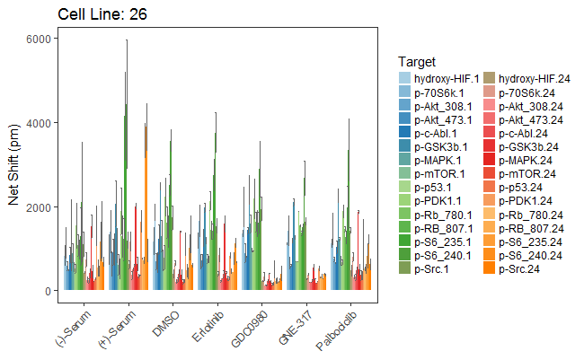

```r
plotEachCellLine <- function(i, filename = "Combined_Averaged.csv"){
    library(readr)
    library(ggplot2)
    library(RColorBrewer)

    #import data
    dat <- read_csv(filename, col_types = cols())

    #create lists for data islation
    cellLineList <- unique(dat$`Cell Line`)
    dat.Timepoint <- dat[dat$`Cell Line` == cellLineList[i],]

    #set error bars
    limits <- aes(ymax = `Relative Shift` + `Standard Deviation`,
                  ymin = `Relative Shift` - `Standard Deviation`)

    #set colors for plot
    colorCount <- length(unique(dat$Target)) * length(unique(dat$`Time Point`))
    getPalette <- colorRampPalette(brewer.pal(8, "Paired"))(colorCount)

    #configure plot, colors, and legend
    plots <- ggplot(data = dat.Timepoint,
        aes(x = Treatment, y = `Relative Shift`, fill = interaction(factor(Target),
                factor(`Time Point`)))) +
        geom_bar(stat = "identity", position = position_dodge(width = 0.9)) +
        ylab("Net Shift (pm)") +
        scale_fill_manual(values = getPalette, name = 'Target') +
        geom_errorbar(limits, width = 0.4, size = 0.3, colour = 'grey40',
                      position = position_dodge(width = 0.9)) +
        theme_bw() + theme(panel.grid = element_blank(),
                           axis.title.x=element_blank()) +
        theme(axis.text.x = element_text(angle = 45, hjust = 1)) +
        theme(legend.key = element_rect(colour = 'white',
                                        fill = 'white'), legend.key.size = unit(0.4, "cm")) +
        ggtitle(paste('Cell Line: ', cellLineList[i], sep=''))

    #plot figure, uncomment to plot
    plots

    #save figure, uncomment to save
    #filename = paste(cellLineList[i], 'png', sep='.')
    #ggsave(plots, file = filename, width = 12, height = 6)
}
plotEachCellLine(1)
```

### Plot as Heatmap for Each Cell Line and Timepoint

```
Non Lab interpolation is deprecated
```

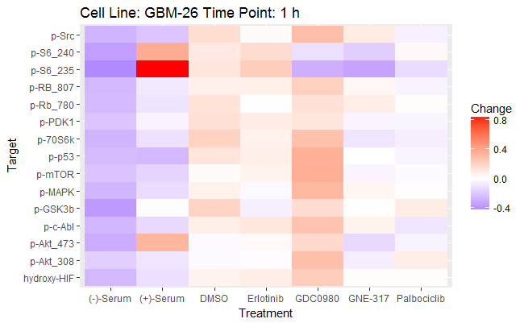

```r
heatmapCellTime <- function(i, filename = "Combined_Averaged.csv"){
    library(readr)
    library(ggplot2)
    library(dplyr)

    #get data
    dat <- read_csv(filename, col_types = cols())

    #create necessary lists and matrix
    cellLineList <- select(dat, `Cell Line`) %>% unlist() %>% unique()
    timePointList <- select(dat, `Time Point`) %>% unlist() %>% unique()
    targetList <- select(dat, `Target`) %>% unlist() %>% unique()
    treatmentList <- select(dat, `Treatment`) %>% unlist() %>% unique()
    cLL <- rep(1:length(cellLineList), length(timePointList))
    tPL <- rep(1:length(timePointList), each = length(cellLineList))
    m <- as.matrix(cbind(tPL, cLL))

    cLL.i <- cellLineList[m[i,2]]
    tPL.i <- timePointList[m[i,1]]
    dat.1 <- filter(dat, `Cell Line` == cLL.i & `Time Point` == tPL.i)
    df <- data.frame()

    for (i in 1:length(targetList)){
        dat.2 <- filter(dat.1, `Target` == targetList[i])
        targetShift <-  select(dat.2, `Relative Shift`) %>% unlist()
        treatment <- select(dat.2, Treatment) %>% unlist()
        meanShift <- mean(targetShift)
        target <- rep(targetList[i], length(treatmentList))
        holder <- numeric()
        for (i in 1:length(targetShift)){
            holder[i] <- (targetShift[i] - meanShift) / meanShift
        }
        tmp <- data.frame(holder, target, treatment)
        df <- rbind(df, tmp)
    }
    treatmentList <- select(dat.1, `Treatment`) %>% unique()
    names(df) <- c('Change', 'Target', 'Treatment')

    #configure heatmap
    plots <- ggplot(df, aes(x = Treatment, y = Target, fill = Change)) +
        geom_tile(stat = "identity") +
        scale_fill_gradient2(low = "blue", mid = "white",
            high = "red", midpoint = 0, space = "rgb",
            na.value = "grey50", guide = "colourbar") +
        ggtitle(paste('Cell Line: GBM-', cLL.i, ' Time Point: ', tPL.i,
                      ' h', sep=''))

    #plot figure, uncomment to plot
    plots

    #write csv file and save figure, uncomment to save
    #filename <- paste("heatmap_", cLL.i, '_', tPL.i, sep='')
    #write_csv(df, paste(filename, '.csv', sep=''))
    #ggsave(plots, file = paste(filename, '.png', sep=''),
    #      width = 10, height = 6)
}
heatmapCellTime(1)
```

### Plot as Heatmap for Each Cell Line

```
Non Lab interpolation is deprecated
```

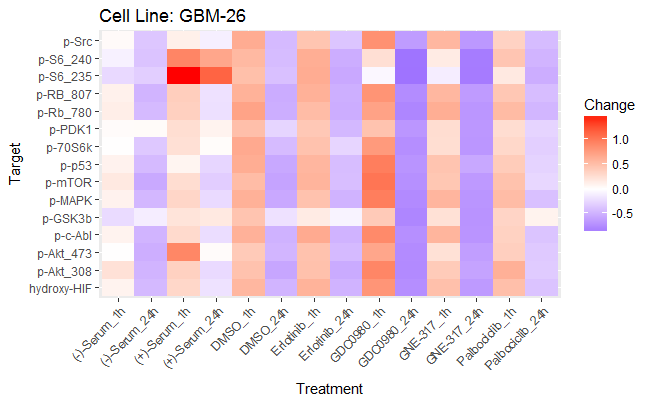

```r
heatmapCellLine <- function(i, filename = "Combined_Averaged.csv"){
    library(readr)
    library(ggplot2)
    library(dplyr)

    #get data
    dat <- read_csv(filename, col_types = cols())

    #create necessary lists and matrix
    cellLineList <- select(dat, `Cell Line`) %>% unlist() %>% unique()
    timePointList <- select(dat, `Time Point`) %>% unlist() %>% unique()
    targetList <- select(dat, `Target`) %>% unlist() %>% unique()
    treatmentList <- select(dat, `Treatment`) %>% unlist() %>% unique()
    cLL <- rep(1:length(cellLineList), length(timePointList))
    tPL <- rep(1:length(timePointList), each = length(cellLineList))
    m <- as.matrix(cbind(tPL, cLL))

    cLL.i <- cellLineList[m[i,2]]
    dat.1 <- filter(dat, `Cell Line` == cLL.i)
    df <- data.frame()

    for (i in 1:length(targetList)){
        dat.2 <- filter(dat.1, `Target` == targetList[i])
        targetShift <-  select(dat.2, `Relative Shift`) %>% unlist
        treatment.a <- select(dat.2, Treatment) %>% unlist()
        treatment.b <- select(dat.2, `Time Point`) %>% unlist()
        treatment <- paste(treatment.a, '_', treatment.b, 'h', sep='')
        meanShift <- mean(targetShift)
        target <- rep(targetList[i], length(treatmentList))
        holder <- numeric()
        for (i in 1:length(targetShift)){
            holder[i] <- (targetShift[i] - meanShift) / meanShift
        }
        tmp <- data.frame(holder, target, treatment)
        df <- rbind(df, tmp)
    }
    treatmentList <- select(dat.1, `Treatment`) %>% unique()
    names(df) <- c('Change', 'Target', 'Treatment')

    #configure heatmap
    plots <- ggplot(df, aes(x = Treatment, y = Target, fill = Change)) +
        geom_tile(stat = "identity") +
        theme(axis.text.x = element_text(angle = 45, hjust = 1)) +
        scale_fill_gradient2(low = "blue", mid = "white",
            high = "red", midpoint = 0, space = "rgb",
            na.value = "grey50", guide = "colourbar") +
        ggtitle(paste('Cell Line: GBM-', cLL.i, sep=''))

    #plot figure, uncomment to plot
    plots

    #write csv file and save figure, uncomment to save
    #filename <- paste("heatmap_", cLL.i, sep='')
    #write_csv(df, paste(filename, '.csv', sep=''))
    #ggsave(plots, file = paste(filename, '.png', sep=''),
    #       width = 10, height = 6)
}
heatmapCellLine(1)
```

### Plot as Heatmap for Each Time Point

```
Non Lab interpolation is deprecated
```

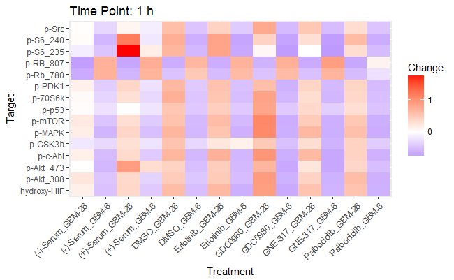

```r
heatmapTimePoint <- function(i, filename = "Combined_Averaged.csv"){
    library(readr)
    library(ggplot2)
    library(dplyr)

    #get data
    dat <- read_csv(filename, col_types = cols())

    #create necessary lists and matrix
    cellLineList <- select(dat, `Cell Line`) %>% unlist() %>% unique()
    timePointList <- select(dat, `Time Point`) %>% unlist() %>% unique()
    targetList <- select(dat, `Target`) %>% unlist() %>% unique()
    treatmentList <- select(dat, `Treatment`) %>% unlist() %>% unique()
    cLL <- rep(1:length(cellLineList), length(timePointList))
    tPL <- rep(1:length(timePointList), each = length(cellLineList))
    m <- as.matrix(cbind(tPL, cLL))

    tPL.i <- timePointList[m[i,1]]
    dat.1 <- filter(dat, `Time Point` == tPL.i)
    df <- data.frame()

    for (i in 1:length(targetList)){
        dat.2 <- filter(dat.1, `Target` == targetList[i])
        targetShift <-  select(dat.2, `Relative Shift`) %>% unlist
        treatment.a <- select(dat.2, Treatment) %>% unlist()
        treatment.b <- select(dat.2, `Cell Line`) %>% unlist()
        treatment <- paste(treatment.a, '_GBM-', treatment.b, sep='')
        meanShift <- mean(targetShift)
        target <- rep(targetList[i], length(treatmentList))
        holder <- numeric()
        for (i in 1:length(targetShift)){
            holder[i] <- (targetShift[i] - meanShift) / meanShift
        }
        tmp <- data.frame(holder, target, treatment)
        df <- rbind(df, tmp)
    }
    treatmentList <- select(dat.1, `Treatment`) %>% unique()
    names(df) <- c('Change', 'Target', 'Treatment')

    #configure heatmap
    plots <- ggplot(df, aes(x = Treatment, y = Target, fill = Change)) +
        geom_tile(stat = "identity") +
        theme(axis.text.x = element_text(angle = 45, hjust = 1)) +
        scale_fill_gradient2(low = "blue", mid = "white",
            high = "red", midpoint = 0, space = "rgb",
            na.value = "grey50", guide = "colourbar") +
        ggtitle(paste('Time Point: ', tPL.i, ' h', sep=''))

    #plot figure, uncomment to plot
    plots

    #write csv file and save figure, uncomment to save
    #filename <- paste("heatmap_", tPL.i, sep='')
    #write_csv(df, paste(filename, '.csv', sep=''))
    #ggsave(plots, file = paste(filename, '.png', sep=''),
    #       width = 10, height = 6)
}
heatmapTimePoint(1)
```

## All Data Plotted by Target

### Hydroxy-HIF-1$\alpha$

> Hypoxia-inducible factor 1 (HIF1) is a heterodimeric transcription factor that plays a critical role in the cellular response to hypoxia (1). The HIF1 complex consists of two subunits, HIF-1$\alpha$ and HIF-1$\beta$, which are basic helix-loop-helix proteins of the PAS (Per, ARNT, Sim) family (2). HIF1 regulates the transcription of a broad range of genes that facilitate responses to the hypoxic environment, including genes regulating angiogenesis, erythropoiesis, cell cycle, metabolism, and apoptosis. The widely expressed HIF-1$\alpha$ is typically degraded rapidly in normoxic cells by the ubiquitin/proteasomal pathway. Under normoxic conditions, HIF-1$\alpha$ is proline hydroxylated leading to a conformational change that promotes binding to the von Hippel Lindau protein (VLH) E3 ligase complex; ubiquitination and proteasomal degradation follows (3,4). Both hypoxic conditions and chemical hydroxylase inhibitors (such as desferrioxamine and cobalt) inhibit HIF-1$\alpha$ degradation and lead to its stabilization. In addition, HIF-1$\alpha$ can be induced in an oxygen-independent manner by various cytokines through the PI3K-AKT-mTOR pathway. *(Quoted from [Cell Signaling](https://www.cellsignal.com/products/primary-antibodies/hydroxy-hif-1a-pro564-d43b5-xp-rabbit-mab/3434))*

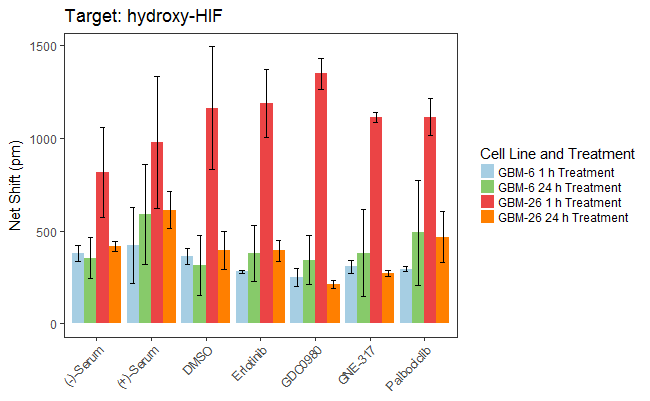

```r
plotEachTarget(1)
```

### Phospho-Akt Thr308

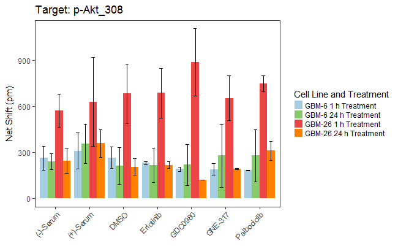

```r
plotEachTarget(2)
```

### Phospho-Akt Ser473

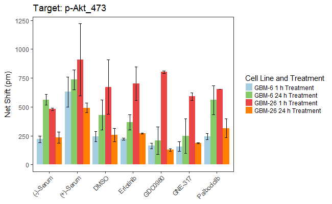

```r
plotEachTarget(3)
```

### Phospho-c-Abl Tyr412

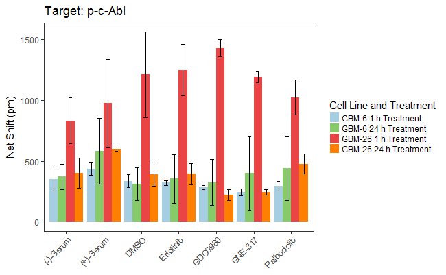

```r
plotEachTarget(4)
```

### Phospho-GSK-3$\beta$ Ser9

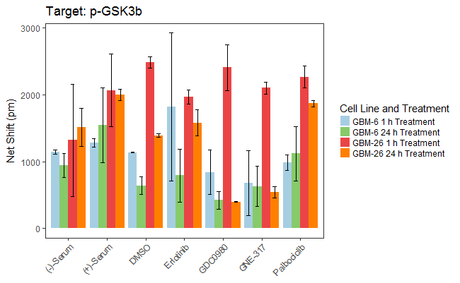

```r
plotEachTarget(5)
```

### Phospho-p44/42 MAPK (Erk1/2) Thr202/Tyr204

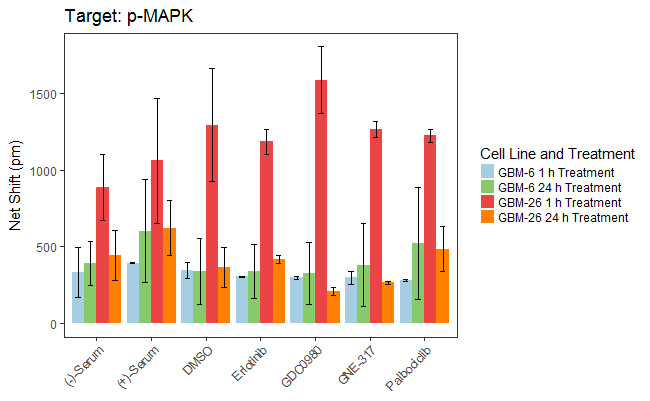

```r
plotEachTarget(6)
```

### Phospho-mTOR Ser2448

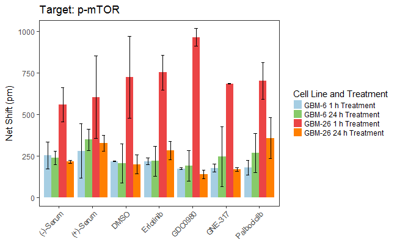

```r
plotEachTarget(7)
```

### Phospho-p53 Ser15

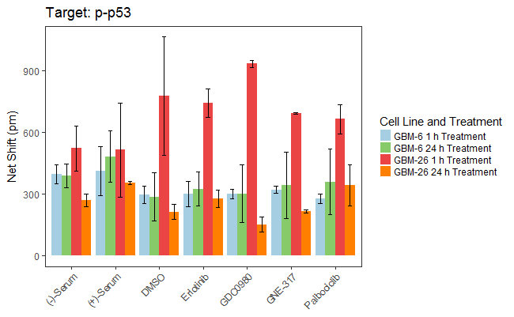

```r
plotEachTarget(8)
```

### Phospho-p70 S6 Kinase Thr389

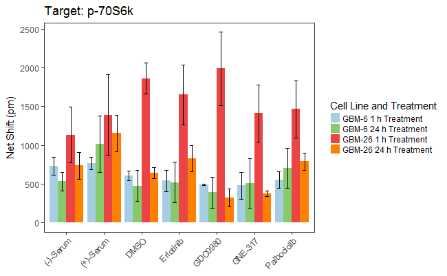

```r
plotEachTarget(9)
```

### Phospho-PDK1 Ser241

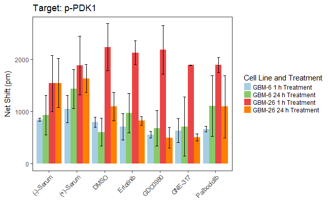

```r
plotEachTarget(10)
```

### Phospho-Rb Ser780

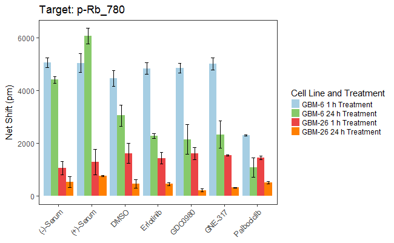

```r
plotEachTarget(11)
```

### Phospho-Rb Ser807/811

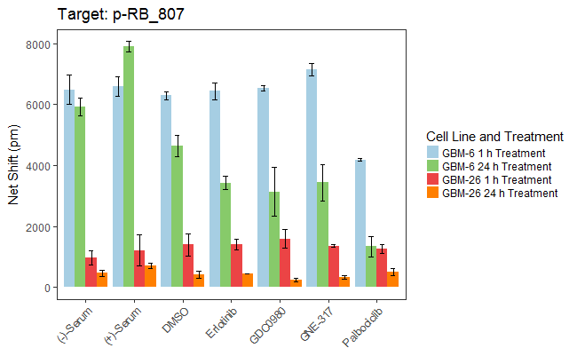

```r
plotEachTarget(12)
```

### Phospho-S6 Ribosomal Protein Ser235/236

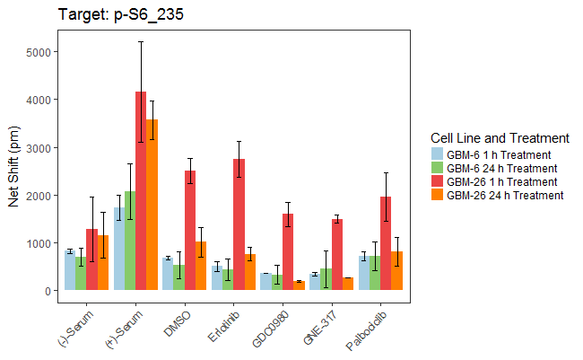

```r
plotEachTarget(13)
```

### Phospho-S6 Ribosomal Protein Ser240/244

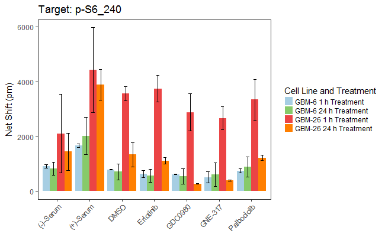

```r
plotEachTarget(14)
```

### Phospho-Src Family Tyr416

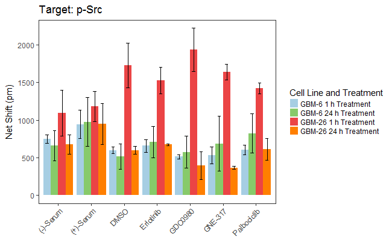

```r
plotEachTarget(15)
```

## All Data Plotted by Treatment and Cell Line

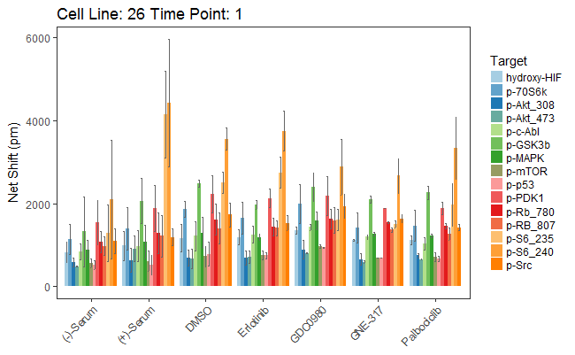

```r
plotEachTimepoint(1,1)
```

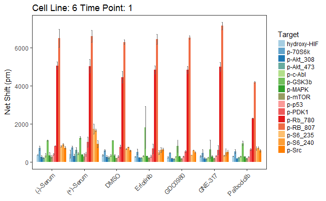

```r
plotEachTimepoint(1,2)
```

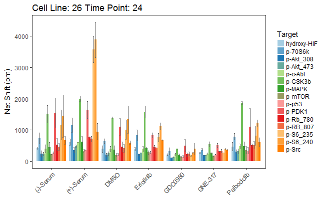

```r
plotEachTimepoint(2,1)
```

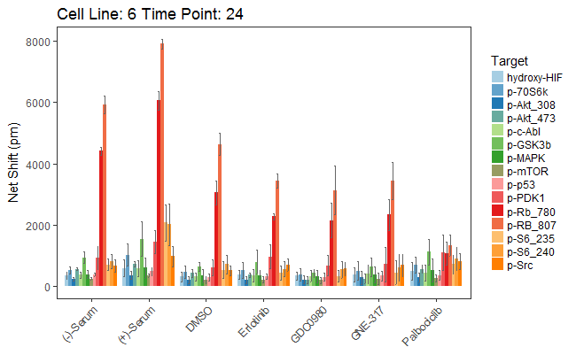

```r
plotEachTimepoint(2,2)
```